# Exercices - Chapter 13

Caio Geraldes

# Easy

1. Which of the following priors will produce more shrinkage in the estimates? (a) $\alpha_{\text{TANK}} \sim \text{Normal}(0,1)$; (b) $\alpha_{\text{TANK}} \sim \text{Normal}(0,2)$?
- Mathematical reasoning

The model (a) is more skeptical of values far away from the mean, so it will shrink the values more than the model (b).

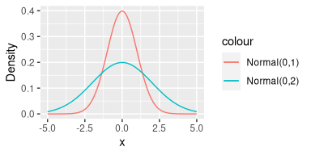

- Using a generative model:

```r
N <- 100
a <- c(0.1, 0.2, 0.3, 0.4, 0.6, 0.7, 0.8, 0.9)
abar <- mean(a)
t <- c(1:8)
l <- sapply(1:8, function(i) sum(rbinom(1, N, prob=a[i])))

dat <- list(N = N, t = t, l = l)

m1 <- quap(alist(l ~ dbinom(N, p), logit(p) <- a[t], a[t] ~ dnorm(0,1)), data = dat)
m2 <- quap(alist(l ~ dbinom(N, p), logit(p) <- a[t], a[t] ~ dnorm(0,2)), data = dat)
```

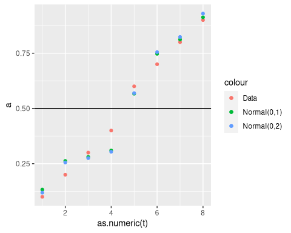

2. Rewrite the following model as a multilevel model.

$$\begin{aligned}
y_i \sim \text{Binomial}(1, p_i)\\
\text{logit}(p_i) = \alpha_{\text{GROUP}_i} + \beta x_i\\
\alpha_{\text{GROUP}} \sim \text{Normal}(0, 1.5)\\
\beta \sim \text{Normal}(0, 0.5)
\end{aligned}$$

- MLM

$$\begin{aligned}
y_i \sim \text{Binomial}(1, p_i)\\
\text{logit}(p_i) = \alpha_{\text{GROUP}_i} + \beta x_i\\
\alpha_{\text{GROUP}} \sim \text{Normal}(\bar{\alpha}, \sigma)\\
\beta \sim \text{Normal}(0, 0.5)\\
\bar{\alpha} \sim \text{Normal}(0,1.5)\\
\sigma \sim \text{Exponential}(1)
\end{aligned}$$

3.Rewrite the following model as a multilevel model.

$$\begin{aligned}
y_i \sim \text{Normal}(\mu_i, \sigma)\\
\mu_i = \alpha_{\text{GROUP}_i} + \beta x_i\\
\alpha_{\text{GROUP}} \sim \text{Normal}(0, 5)\\
\beta \sim \text{Normal}(0, 1)\\
\sigma \sim \text{Exponential}(1)
\end{aligned}$$
- MLM:

$$\begin{aligned}
y_i \sim \text{Normal}(\mu_i, \sigma)\\
\mu_i = \alpha_{\text{GROUP}_i} + \beta x_i\\
\alpha_{\text{GROUP}} \sim \text{Normal}(\bar{\alpha}, \sigma_\alpha)\\
\beta \sim \text{Normal}(0, 1)\\
\bar{\alpha} \sim \text{Normal}(0,5)\\
\sigma, \sigma_\alpha \sim \text{Exponential}(1)
\end{aligned}$$

4. Write a mathematical model formula for a Poisson regression with varying intercepts.

$$\begin{aligned}
A_i \sim \text{Poisson}(\lambda_i)\\
\log(\lambda_i) = \alpha_{B_i} + \beta x\\
\alpha_j \sim \text{Normal}(\bar{\alpha}, \sigma_\alpha)\\
\beta \sim \text{Normal}(0,1)\\
\bar{\alpha} \sim \text{Normal}(0,1)\\
\sigma_\alpha \sim \text{Exponential}(1)
\end{aligned}$$

5. Write a mathematical model formula for a Poisson regression with two different kinds of varying intercepts, a cross-classified model.

$$\begin{aligned}
A_i \sim \text{Poisson}(\lambda_i)\\
\log(\lambda_i) = \alpha_{B_i} + \gamma_{C_i} + \beta x\\
\alpha_j \sim \text{Normal}(\bar{\alpha}, \sigma_\alpha)\\
\gamma_k \sim \text{Normal}(0, \sigma_\gamma)\\
\beta \sim \text{Normal}(0,1)\\
\bar{\alpha} \sim \text{Normal}(0,1)\\
\sigma_\alpha, \sigma_\gamma \sim \text{Exponential}(1)
\end{aligned}$$

# Medium

1. Revisit the Reed frog survival data, data(reedfrogs), and add the predation and size treatment variables to the varying intercepts model. Consider models with either main effect alone, both main effects, as well as a model including both and their interaction. Instead of focusing on inferences about these two predictor variables, focus on the inferred variation across tanks. Explain why it changes as it does across models.

```r
data("reedfrogs")
reed.df <- tibble(reedfrogs)
reed.df$tank <- 1:48
reed.df
```

| density | pred | size | surv | propsurv | tank |
| --- | --- | --- | --- | --- | --- |
| 10 | no | big | 9 | 0.9000000 | 1 |
| 10 | no | big | 10 | 1.0000000 | 2 |
| 10 | no | big | 7 | 0.7000000 | 3 |
| 10 | no | big | 10 | 1.0000000 | 4 |
| 10 | no | small | 9 | 0.9000000 | 5 |
| 10 | no | small | 9 | 0.9000000 | 6 |
| 10 | no | small | 10 | 1.0000000 | 7 |
| 10 | no | small | 9 | 0.9000000 | 8 |
| 10 | pred | big | 4 | 0.4000000 | 9 |
| 10 | pred | big | 9 | 0.9000000 | 10 |

[output cut: 38 more lines]

```r
dat <- list(
    D = reed.df$density,
    size = ifelse(reed.df$size=="small", 1L, 2L),
    pred = ifelse(reed.df$pred == "no", 0L, 1L),
    tank = 1:nrow(reed.df),
    S = reed.df$surv
)
as.data.frame(dat)
```

| D | size | pred | tank | S |
| --- | --- | --- | --- | --- |
| 10 | 2 | 0 | 1 | 9 |
| 10 | 2 | 0 | 2 | 10 |
| 10 | 2 | 0 | 3 | 7 |
| 10 | 2 | 0 | 4 | 10 |
| 10 | 1 | 0 | 5 | 9 |
| 10 | 1 | 0 | 6 | 9 |
| 10 | 1 | 0 | 7 | 10 |
| 10 | 1 | 0 | 8 | 9 |
| 10 | 2 | 1 | 9 | 4 |
| 10 | 2 | 1 | 10 | 9 |

[output cut: 38 more lines]

```r
# tank
reed.mB <- ulam(
    alist(
        S ~ dbinom(D, p),
        logit(p) <- abar + zA[tank]*sA,
        vector[48]:zA ~ normal(0,1),
        abar ~ normal(0,1.5),
        sA ~ exponential(1),

        gq> vector[48]:a <<- abar + zA*sA
    ),
    data = dat, chains = 4, cores = 4,
    log_lik = TRUE,
    file = "models/reed.mB"
)

# tank, pred
reed.mP <- ulam(
    alist(
        S ~ binomial(D, p),
        logit(p) <- abar + zA[tank]*sA + b*pred,

        vector[48]:zA ~ normal(0,1),
        b ~ normal(-0.5,1),
        abar ~ normal(0,1.5),
        sA ~ exponential(1),

        gq> vector[48]:a <<- abar + zA*sA
    ),
    data = dat, chains = 4, cores = 4,
    log_lik = TRUE,
    file = "models/reed.mP"
)

# tank, size
reed.mS <- ulam(
    alist(
        S ~ binomial(D, p),
        logit(p) <- abar + zA[tank]*sA + g[size],

        vector[48]:zA ~ normal(0,1),
        vector[2]:g ~ normal(0, 0.5),
        abar ~ normal(0,1.5),
        sA ~ exponential(1),

        gq> vector[48]:a <<- abar + zA*sA
    ),
    data = dat, chains = 4, cores = 4,
    log_lik = TRUE,
    file = "models/reed.mS"
)

# tank, size, pred
reed.mSP <- ulam(
    alist(
        S ~ binomial(D, p),
        logit(p) <- abar + zA[tank]*sA + g[size] + b*pred,

        vector[48]:zA ~ normal(0,1),
        b ~ normal(-0.5,1),
        vector[2]:g ~ normal(0, 0.5),
        abar ~ normal(0,1.5),
        sA ~ exponential(1),

        gq> vector[48]:a <<- abar + zA*sA
    ),
    data = dat, chains = 4, cores = 4,
    log_lik = TRUE,
    file = "models/reed.mSP"
)

# tank, size, pred, iteraction
reed.mSPi <- ulam(
    alist(
        S ~ binomial(D, p),
        logit(p) <- abar + zA[tank]*sA + g[size] + b[size]*pred,

        vector[48]:zA ~ normal(0,1),
        vector[2]:b ~ normal(-0.5,1),
        vector[2]:g ~ normal(0, 0.5),
        abar ~ normal(0,1.5),
        sA ~ exponential(1),

        gq> vector[48]:a <<- abar + zA*sA
    ),
    data = dat, chains = 4, cores = 4,
    log_lik = TRUE,
    file = "models/reed.mSPi"
)
```

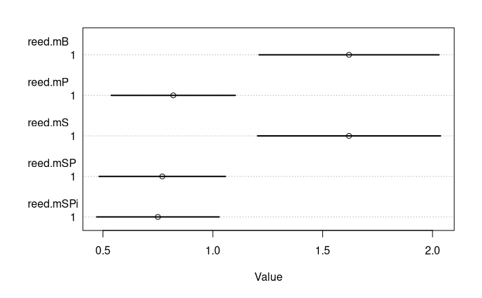

```r
coeftab_plot(coeftab(reed.mB, reed.mP, reed.mS, reed.mSP, reed.mSPi), pars="sA")
```

2. Compare the models you fit just above, using WAIC. Can you reconcile the differences in WAIC with the posterior distributions of the models?

```r
compare(reed.mB, reed.mP, reed.mS, reed.mSP, reed.mSPi)
```

|  | WAIC | SE | dWAIC | dSE | pWAIC | weight |
| --- | --- | --- | --- | --- | --- | --- |
| reed.mP | 199.2 | 9.07 | 0.0 | NA | 19.2 | 0.29 |
| reed.mB | 199.8 | 7.18 | 0.6 | 5.46 | 20.8 | 0.22 |
| reed.mSPi | 200.1 | 9.09 | 0.9 | 3.21 | 19.3 | 0.18 |
| reed.mS | 200.3 | 7.10 | 1.2 | 5.74 | 21.0 | 0.16 |
| reed.mSP | 200.7 | 8.89 | 1.5 | 1.99 | 19.5 | 0.14 |

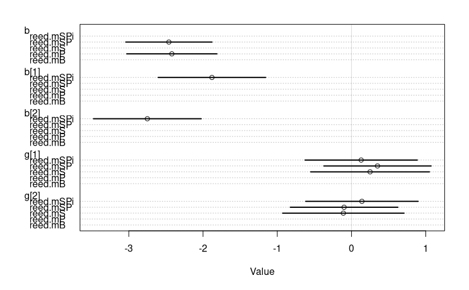

```r
coeftab_plot(coeftab(reed.mB, reed.mP, reed.mS, reed.mSP, reed.mSPi), pars=c("b", "b[1]", "b[2]", "g[1]", "g[2]"))
```

3. Re-estimatethe basic Reed frog varying intercept model, butnow using a Cauchy distribution in place of the Gaussian distribution for the varying intercepts. That is, fit this model:
   $$\begin{aligned}
   S_i ∼ \text{Binomial}(D_i, p_i)\\
   \text{logit}(pi) = \alpha_{\text{tank}_i}\\
   \alpha_\text{tank} \sim \text{Cauchy}(\alpha, \sigma)\\
   \bar{\alpha} \sim \text{Normal}(0, 1)\\
   \sigma \sim \text{Exponential}(1)
   \end{aligned}$$

```r
reed.mBa <- ulam(
    alist(
        S ~ binomial(D, p),
        logit(p) <- a[tank],
        vector[48]:a ~ dcauchy(abar, sigma),
        abar ~ normal(0,1),
        sigma ~ exponential(1)
    ),
    data = dat, chains=4, cores=4,
    log_lik = TRUE,
    file = "models/reed.mBa"
)
```

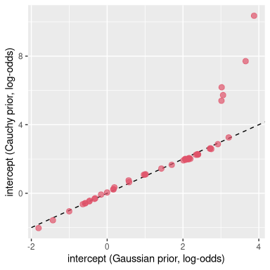

The Cauchy distribution allow the probabilities to explode in the log-odds scale, i.e. does not cause enough shrinkage in the posterior distribution.

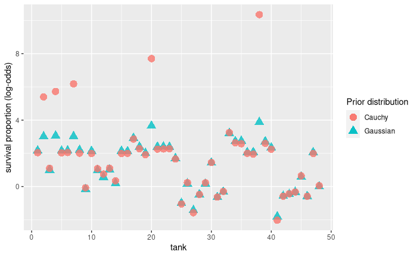

4. Now use a Student-t distribution with ν = 2 for the intercepts:

$$\alpha_\text{tank} ∼ \text{Student}(2, \alpha, \sigma)$$

Refer back to the Student-t example in Chapter 7 (page 234), if necessary. Compare the resulting posterior to both the original model and the Cauchy model in 13M3. Can you explain the differences and similarities in shrinkage in terms of the properties of these distributions?

```r
reed.mBb <- ulam(
    alist(
        S ~ binomial(D, p),
        logit(p) <- a[tank],
        vector[48]:a ~ dstudent(2, abar, sigma),
        abar ~ normal(0,1),
        sigma ~ exponential(1)
    ),
    data = dat, chains=4, cores=4,
    log_lik = TRUE,
    file = "models/reed.mBb"
)
```

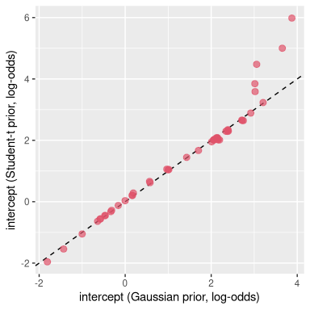

```r
ps.reed.mBb <- extract.samples(reed.mBb)
a.mBb <- apply(ps.reed.mBb$a, 2, mean)

tibble(x=a.mB, y=a.mBb) %>%
    ggplot(aes(x=x, y=y)) +
    geom_abline(intercept = 0, slope = 1, linetype=2) +
    geom_point(color=2, size=2.5, alpha=0.7) +
    xlab("intercept (Gaussian prior, log-odds)") +
    ylab("intercept (Student-t prior, log-odds)")
```

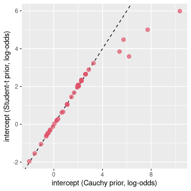

```r
tibble(x=a.mBa, y=a.mBb) %>%
    ggplot(aes(x=x, y=y)) +
    geom_abline(intercept = 0, slope = 1, linetype=2) +
    geom_point(color=2, size=2.5, alpha=0.7) +
    xlab("intercept (Cauchy prior, log-odds)") +
    ylab("intercept (Student-t prior, log-odds)")
```

As the Student-t distribution is has thicker tails than the Gaussian, and thiner than the Cauchy, it falls in between both models in the most extreme tanks.

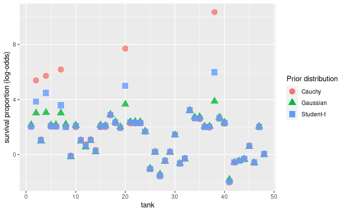